# Lab 12 Homework

Javier Vidal

2025-02-24

## Instructions

Answer the following questions and complete the exercises in RMarkdown. Please embed all of your code and push your final work to your repository. Your final lab report should be organized, clean, and run free from errors. Remember, you must remove the `#` for the included code chunks to run. Be sure to add your name to the author header above. For any included plots, make sure they are clearly labeled. You are free to use any plot type that you feel best communicates the results of your analysis.

Make sure to use the formatting conventions of RMarkdown to make your report neat and clean!

## Load the libraries

```r
library(tidyverse)
library(janitor)
library(naniar)
```

```r
options(scipen = 999)
```

## Resources

The idea for this assignment came from [Rebecca Barter’s](http://www.rebeccabarter.com/blog/2017-11-17-ggplot2_tutorial/) ggplot tutorial so if you get stuck this is a good place to have a look.

## Gapminder

For this assignment, we are going to use the dataset [gapminder](https://cran.r-project.org/web/packages/gapminder/index.html). Gapminder includes information about economics, population, and life expectancy from countries all over the world. You will need to install it before use.

```r
#install.packages("gapminder")
library("gapminder")
```

```r
gapminder <- gapminder
```

1. Use the function(s) of your choice to get an idea of the overall structure of the data frame, including its dimensions, column names, variable classes, etc. As part of this, determine how NA’s are treated in the data.

```r
glimpse(gapminder)
```

```
## Rows: 1,704
## Columns: 6
## $ country   <fct> "Afghanistan", "Afghanistan", "Afghanistan", "Afghanistan", …
## $ continent <fct> Asia, Asia, Asia, Asia, Asia, Asia, Asia, Asia, Asia, Asia, …
## $ year      <int> 1952, 1957, 1962, 1967, 1972, 1977, 1982, 1987, 1992, 1997, …
## $ lifeExp   <dbl> 28.801, 30.332, 31.997, 34.020, 36.088, 38.438, 39.854, 40.8…
## $ pop       <int> 8425333, 9240934, 10267083, 11537966, 13079460, 14880372, 12…
## $ gdpPercap <dbl> 779.4453, 820.8530, 853.1007, 836.1971, 739.9811, 786.1134, …
```

```r
miss_var_summary(gapminder)
```

```
## # A tibble: 6 × 3
##   variable  n_miss pct_miss
##   <chr>      <int>    <num>
## 1 country        0        0
## 2 continent      0        0
## 3 year           0        0
## 4 lifeExp        0        0
## 5 pop            0        0
## 6 gdpPercap      0        0
```

2. How many countries are represented in this dataset? Make a table and a plot that shows the number of countries by continent.

```r
gapminder %>%
  group_by(continent) %>%
  summarize(n=n_distinct(country))
```

```
## # A tibble: 5 × 2
##   continent     n
##   <fct>     <int>
## 1 Africa       52
## 2 Americas     25
## 3 Asia         33
## 4 Europe       30
## 5 Oceania       2
```

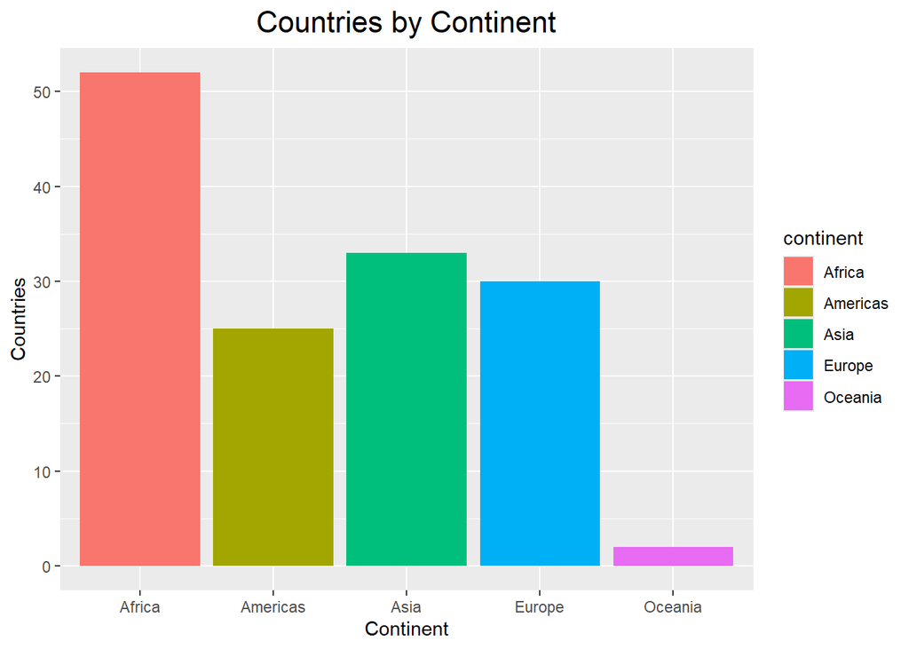

```r
gapminder %>%
  group_by(continent) %>%
  summarize(n=n_distinct(country)) %>%
  ggplot(aes(x=continent, y = n, fill = continent))+
  geom_col()+
  labs(title = "Countries by Continent",
       x = "Continent",
       y = "Countries")+
  theme(plot.title=element_text(size=rel(1.5), hjust=.5))
```

3. Which country has the largest population growth since 1952? Show this as a table.

```r
gapminder %>%
  select(country, year, pop) %>%
  pivot_wider(names_from = year,
              values_from = pop) %>%
  mutate(population_growth = `2007` - `1952`) %>%
  select(country, population_growth) %>%
  arrange(-population_growth)
```

```
## # A tibble: 142 × 2
##    country       population_growth
##    <fct>                     <int>
##  1 China                 762419569
##  2 India                 738396331
##  3 United States         143586947
##  4 Indonesia             141495000
##  5 Brazil                133408087
##  6 Pakistan              127924057
##  7 Bangladesh            103561480
##  8 Nigeria               101912068
##  9 Mexico                 78556574
## 10 Philippines            68638596
## # ℹ 132 more rows
```

China has the largest population growth since 1952

4. Make a plot that shows population growth for the country you found in question #3. This plot should show the change over time.

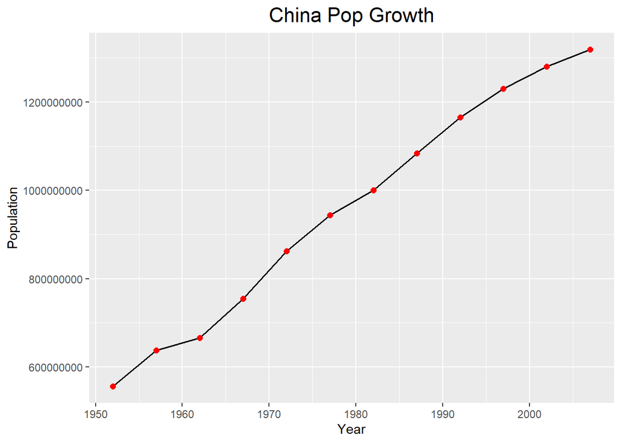

```r
gapminder %>%
  filter(country == "China") %>%
  ggplot(aes(x = year, y = pop))+
  geom_line(size = .7)+
  geom_point(color = "red", size = 2)+
  labs(title = "China Pop Growth", x = "Year", y = "Population")+
  theme(plot.title=element_text(size = rel(1.5), hjust = 0.5))
```

5. How has global life expectancy changed between 1952 and 2007? Show the min, mean, and max for all countries in the dataset. Show this as a table.

```r
gapminder %>%
  group_by(country) %>%
  filter(year<=2007 & year>=1952) %>%
  summarize(min_lifeexp = min(lifeExp),
            mean_lifeexp = mean(lifeExp),
            max_lifeexp = max(lifeExp))
```

```
## # A tibble: 142 × 4
##    country     min_lifeexp mean_lifeexp max_lifeexp
##    <fct>             <dbl>        <dbl>       <dbl>
##  1 Afghanistan        28.8         37.5        43.8
##  2 Albania            55.2         68.4        76.4
##  3 Algeria            43.1         59.0        72.3
##  4 Angola             30.0         37.9        42.7
##  5 Argentina          62.5         69.1        75.3
##  6 Australia          69.1         74.7        81.2
##  7 Austria            66.8         73.1        79.8
##  8 Bahrain            50.9         65.6        75.6
##  9 Bangladesh         37.5         49.8        64.1
## 10 Belgium            68           73.6        79.4
## # ℹ 132 more rows
```

6. Make a plot that shows how mean life expectancy has changed over time for each continent. What is your interpretation of what happened in Africa between 1987 and 2002?

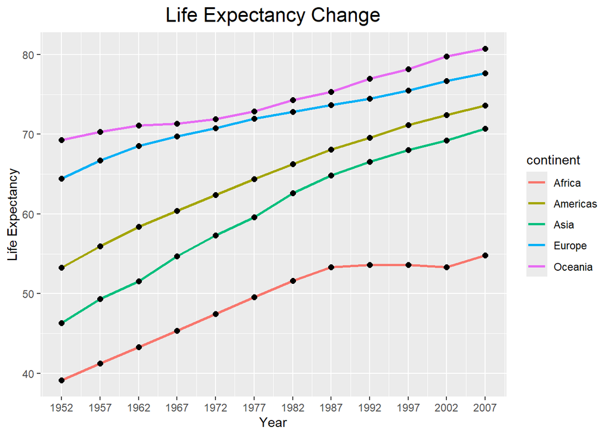

```r
gapminder %>%
  group_by(continent, year) %>%  #grouping by continent and year
  summarize(mean_lifeexp = mean(lifeExp), .groups = 'keep') %>% #getting the mean life expectancy
  ggplot(aes(x = year, y = mean_lifeexp, color = continent))+
           geom_line(size = 1)+
  geom_point(color = "black", size = 2)+
  scale_x_continuous(breaks=unique(gapminder$year))+
  labs(title = "Life Expectancy Change", x = "Year", y = "Life Expectancy")+
  theme(plot.title=element_text(size = rel(1.5), hjust = 0.5))
```

There were many challenges that prevented an increase in life expectancy and health during those years.

7. We are interested in the relationship between per capita GDP and life expectancy; i.e. does having more money help you live longer? Show this as a plot.

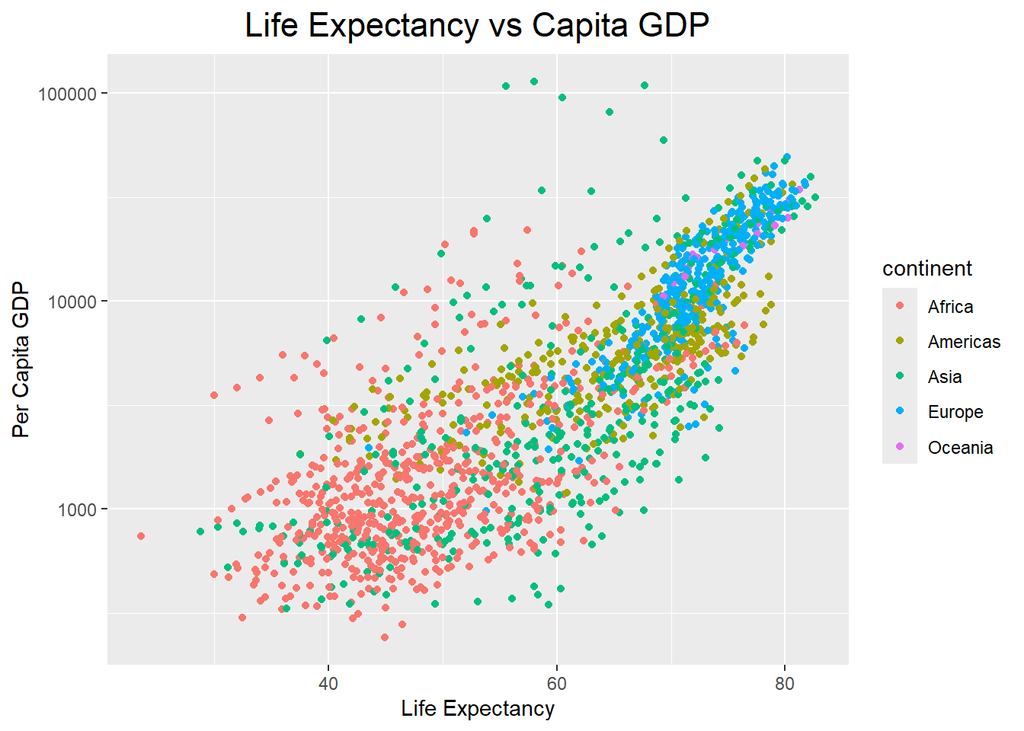

```r
gapminder %>%
  ggplot(aes(x=lifeExp, y=gdpPercap, color = continent))+
  geom_point()+
  scale_y_log10()+
  labs(title = "Life Expectancy vs Capita GDP",  x = "Life Expectancy", y = "Per Capita GDP")+
  theme(plot.title=element_text(size = rel(1.5), hjust = .5))
```

The plot does show a relation between having more money and living longer.

8. Which five countries have had the highest GDP per capita growth over the years represented in this dataset? Show this as a table.

```r
gapminder %>%
  select(country, year, gdpPercap) %>%
  pivot_wider(names_from = year,
              values_from = gdpPercap) %>%
  mutate(Percap_growth = `2007` - `1952`) %>%
  select(country, everything()) %>%
  arrange(-Percap_growth)
```

```
## # A tibble: 142 × 14
##    country `1952` `1957` `1962` `1967` `1972` `1977` `1982` `1987` `1992` `1997`
##    <fct>    <dbl>  <dbl>  <dbl>  <dbl>  <dbl>  <dbl>  <dbl>  <dbl>  <dbl>  <dbl>
##  1 Singap…  2315.  2843.  3675.  4977.  8598. 11210. 15169. 18862. 24770. 33519.
##  2 Norway  10095. 11654. 13450. 16362. 18965. 23311. 26299. 31541. 33966. 41283.
##  3 Hong K…  3054.  3629.  4693.  6198.  8316. 11186. 14561. 20038. 24758. 28378.
##  4 Ireland  5210.  5599.  6632.  7656.  9531. 11151. 12618. 13873. 17559. 24522.
##  5 Austria  6137.  8843. 10751. 12835. 16662. 19749. 21597. 23688. 27042. 29096.
##  6 United… 13990. 14847. 16173. 19530. 21806. 24073. 25010. 29884. 32004. 35767.
##  7 Iceland  7268.  9244. 10350. 13320. 15798. 19655. 23270. 26923. 25144. 28061.
##  8 Japan    3217.  4318.  6577.  9848. 14779. 16610. 19384. 22376. 26825. 28817.
##  9 Nether…  8942. 11276. 12791. 15363. 18795. 21209. 21399. 23651. 26791. 30246.
## 10 Taiwan   1207.  1508.  1823.  2644.  4063.  5597.  7426. 11055. 15216. 20207.
## # ℹ 132 more rows
## # ℹ 3 more variables: `2002` <dbl>, `2007` <dbl>, Percap_growth <dbl>
```

Singapore, Norway, Hong Kong, Ireland, and Austria have had the highest GDP per capita growth over the years.

9. How does per capita GDP growth compare between these same five countries? Show this as a plot.

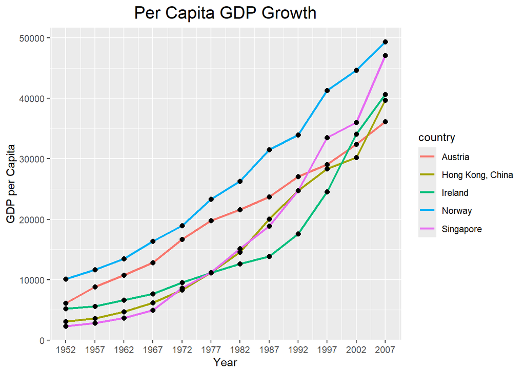

```r
gapminder %>%
  filter(country %in% c("Singapore", "Norway", "Hong Kong, China", "Ireland", "Austria")) %>%
  ggplot(aes(x = year, y = gdpPercap, color = country))+
           geom_line(size = 1)+
  geom_point(color = "black", size = 2)+
  scale_x_continuous(breaks=unique(gapminder$year))+
  labs(title = "Per Capita GDP Growth", x = "Year", y = "GDP per Capita")+
  theme(plot.title=element_text(size = rel(1.5), hjust = 0.5))
```

10. Do one analysis of your choice that includes a table and plot as outputs.

```r
Oceania_pop <- gapminder %>%
  group_by(country) %>%
  filter(continent == "Oceania") %>%
  select(country, year, pop)
Oceania_pop
```

```
## # A tibble: 24 × 3
## # Groups:   country [2]
##    country    year      pop
##    <fct>     <int>    <int>
##  1 Australia  1952  8691212
##  2 Australia  1957  9712569
##  3 Australia  1962 10794968
##  4 Australia  1967 11872264
##  5 Australia  1972 13177000
##  6 Australia  1977 14074100
##  7 Australia  1982 15184200
##  8 Australia  1987 16257249
##  9 Australia  1992 17481977
## 10 Australia  1997 18565243
## # ℹ 14 more rows
```

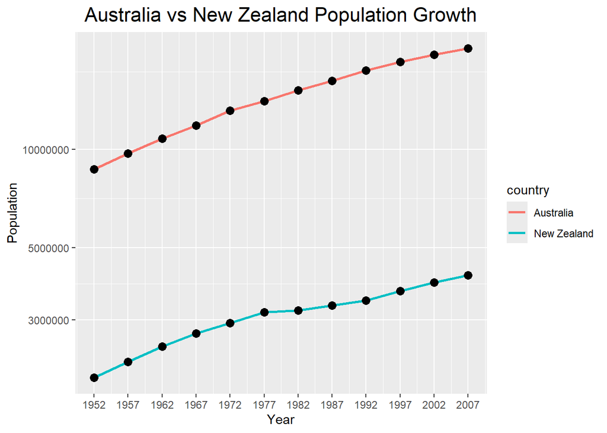

```r
Oceania_pop %>%
  ggplot(aes(x=year, y = pop, color = country))+
  geom_line(size = 1)+
  geom_point(color="black", size = 3)+
  labs(title = "Australia vs New Zealand Population Growth", x = "Year", y = "Population")+
  theme(plot.title=element_text(size=rel(1.5), hjust = .5))+
   scale_x_continuous(breaks=unique(Oceania_pop$year))+
  scale_y_log10()
```

Analysis of the difference in population growth between the two countries of the Oceania continent

## Knit and Upload

Please knit your work as a .pdf or .html file and upload to Canvas. Homework is due before the start of the next lab. No late work is accepted. Make sure to use the formatting conventions of RMarkdown to make your report neat and clean!